[figure not shown]

# Indicateurs agricoles CIC sécheresse

Normandie

**Situation au 02/10/2026**

## 1 Répartition de la surface irrigable par niveau de restriction

**Tableau et graphique 1 : Répartition de la surface irrigable par niveau de restriction (en hectare)**

| Département | Vigilance | Alerte | Alerte renforcée | Crise |
| --- | --- | --- | --- | --- |
| Calvados | 8 579 | 721 | 2 478 | 1 250 |
| Eure | 19 724 | 4 474 | 0 | 5 456 |
| Manche | 0 | 0 | 7 782 | 757 |
| Orne | 733 | 2 168 | 8 | 1 566 |
| Seine-Maritime | 5 326 | 1 128 | 22 | 0 |

Source : Agreste Recensement agricole 2020, VigiEau data.gouv.fr au 02/10/2026 Champ : Normandie. Les exploitations dont le siège n’est pas localisé dans une zone VigiEau active n’apparaissent pas sauf dans le total départemental Traitement : MAASA/SG/SSP/MICeTeM et SRISE Normandie

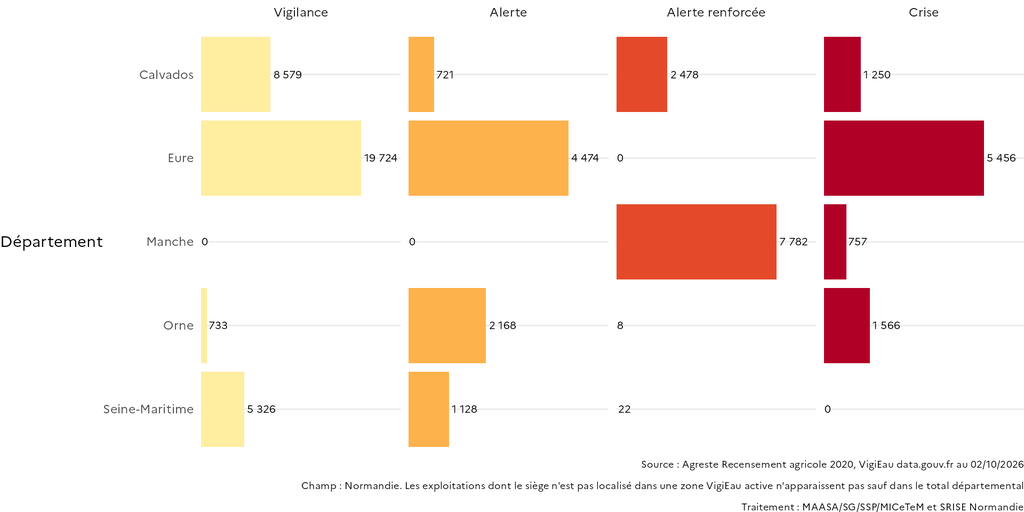

## 2 Répartition des exploitations irrigables par niveau de restriction

**Tableau et graphique 2 : Répartition des exploitations avec des surfaces irrigables par niveau de restriction**

| Département | Vigilance | Alerte | Alerte renforcée | Crise |
| --- | --- | --- | --- | --- |
| Calvados | 198 | 92 | 132 | 130 |
| Eure | 398 | 136 | 0 | 82 |
| Manche | 0 | 0 | 556 | 134 |
| Orne | 50 | 78 | 6 | 102 |
| Seine-Maritime | 430 | 76 | 14 | 0 |

Source : Agreste Recensement agricole 2020, VigiEau data.gouv.fr au 02/10/2026 Champ : Normandie. Les exploitations dont le siège n’est pas localisé dans une zone VigiEau active n’apparaissent pas sauf dans le total départemental Traitement : MAASA/SG/SSP/MICeTeM et SRISE Normandie

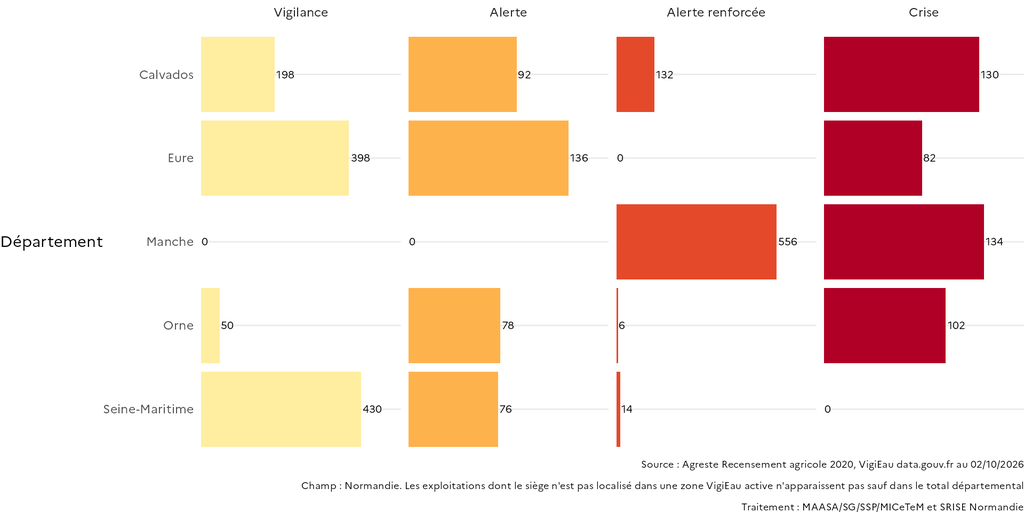

## 3 Répartition des exploitations avec élevage par niveau de restriction

**Tableau et graphique 3 : Répartition des exploitations avec élevage par niveau de restriction**

| Département | Vigilance | Alerte | Alerte renforcée | Crise |
| --- | --- | --- | --- | --- |
| Calvados | 1 380 | 1 632 | 1 172 | 3 190 |
| Eure | 2 268 | 952 | 0 | 260 |
| Manche | 0 | 0 | 9 692 | 3 120 |
| Orne | 998 | 2 146 | 338 | 3 718 |
| Seine-Maritime | 4 670 | 1 718 | 394 | 0 |

Source : Agreste Recensement agricole 2020, VigiEau data.gouv.fr au 02/10/2026 Champ : Normandie. Les exploitations dont le siège n’est pas localisé dans une zone VigiEau active n’apparaissent pas sauf dans le total départemental Traitement : MAASA/SG/SSP/MICeTeM et SRISE Normandie

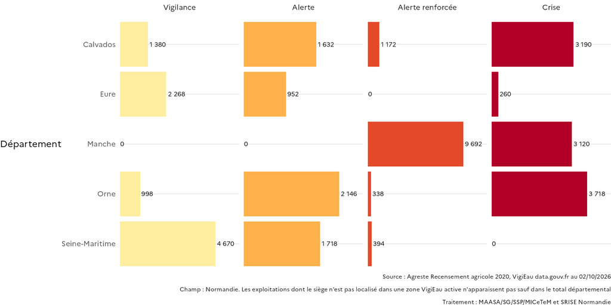

## 4 Répartition des prélèvements par niveau de restriction

**Tableau et graphique 4 : Répartition des prélèvements par niveau de restriction en m**<sup>3</sup> (référence 2023)

| Département | Vigilance | Alerte | Alerte renforcée | Crise |
| --- | --- | --- | --- | --- |
| Calvados | 1 221 972 | 73 323 | 505 570 | 98 599 |
| Eure | 2 213 010 | 779 352 | 0 | 322 836 |
| Manche | 0 | 0 | 2 922 516 | 256 499 |
| Orne | 13 630 | 42 543 | 0 | 25 896 |
| Seine-Maritime | 595 232 | 26 296 | 0 | 0 |

Source : BNPE 2023, VigiEau data.gouv.fr au 02/10/2026 Champ : Normandie. Traitement : MAASA/SG/SSP/MICeTeM et SRISE Normandie

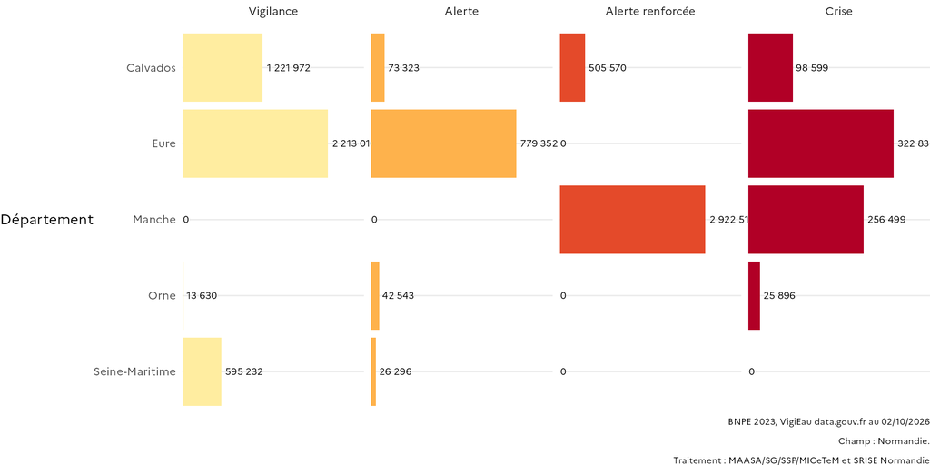

## 5 Répartition des exploitations d’élevages détenant des surfaces irrigables par niveau de restriction

**Tableau et graphique 5 : Répartition des exploitations d’élevages détenant des surfaces irrigables par niveau de restriction**

| Département | Vigilance | Alerte | Alerte renforcée | Crise |
| --- | --- | --- | --- | --- |
| Calvados | 42 | 40 | 38 | 36 |
| Eure | 76 | 42 | 0 | 20 |
| Manche | 0 | 0 | 156 | 36 |
| Orne | s | 36 | s | 30 |
| Seine-Maritime | 128 | 24 | 0 | 0 |

s: secret statistique Source : Agreste Recensement agricole 2020, VigiEau data.gouv.fr au 02/10/2026 Champ : Normandie. Les exploitations dont le siège n’est pas localisé dans une zone VigiEau active n’apparaissent pas sauf dans le total départemental Traitement : MAASA/SG/SSP/MICeTeM et SRISE Normandie

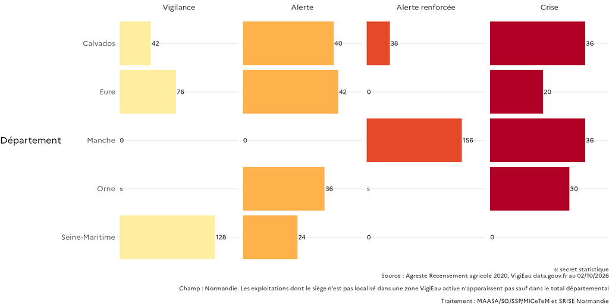

## 6 Répartition de la surface irrigable des exploitations d’élevage détenant des surfaces irrigables par niveau de restriction

**Tableau et graphique 6 : Répartition de la surface irrigable des exploitations d’élevage détenant des surfaces irrigables par niveau de restriction (en hectare)**

| Département | Vigilance | Alerte | Alerte renforcée | Crise |
| --- | --- | --- | --- | --- |
| Calvados | 2 878 | 237 | 1 162 | 332 |
| Eure | 2 079 | 1 584 | 0 | 1 192 |
| Manche | 0 | 0 | 2 201 | 223 |
| Orne | s | 1 421 | s | 970 |
| Seine-Maritime | 3 102 | 721 | 0 | 0 |

s: secret statistique Source : Agreste Recensement agricole 2020, VigiEau data.gouv.fr au 02/10/2026 Champ : Normandie. Les exploitations dont le siège n’est pas localisé dans une zone VigiEau active n’apparaissent pas sauf dans le total départemental Traitement : MAASA/SG/SSP/MICeTeM et SRISE Normandie

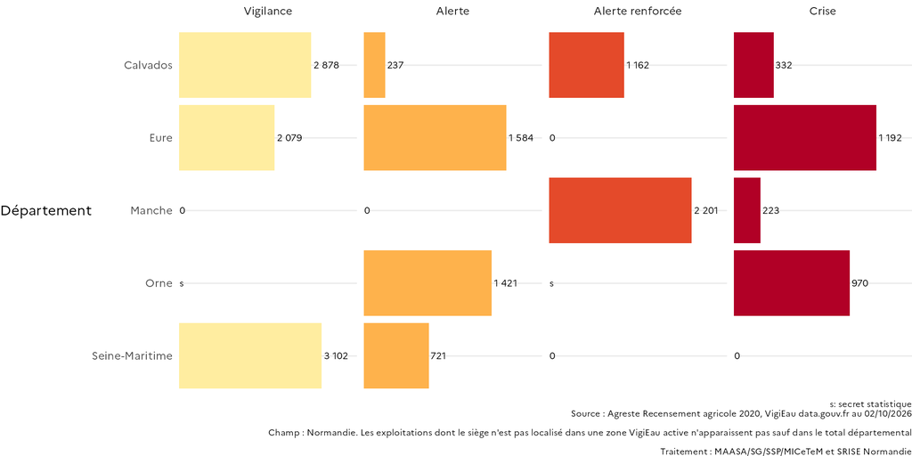

DRAAF Normandie / SRISE

**Avertissements** : les exploitations sont localisées à leur siège avec une précision de 1 km. Elles sont placées dans leurs zones VigiEau, mais en cas de doublons sur le même type de ressource, elles sont rattachées à la zone dont le centre est le plus proche.  
Seules les ressources ESU et ESO sont prises en compte (pas AEP). Si une exploitation est dans des zones de différents type de ressource, elle prend la valeur du niveau de gravité le plus élevé.  
Les surfaces irrigables par types de culture sont estimées via les surfaces irriguées.  
Quelques exploitations en limite de département ne sont pas prises en compte compte tenu de la qualité des données.  
Les données sont arrondies à l’unité.

## Pour en savoir plus

Zonages Vigieau du jour : [voir la page VigiEau](https://vigieau.gouv.fr/carte/)